# DNA/RNA Dynamics - Module 2 - Final Project

Leonardo Politi

2023-06-28

```r
suppressMessages(library(minfi))

data_path = "C:/Users/cicci/Desktop/DRD_project/data/Input"
clean_Manifest_path = "C:/Users/cicci/Desktop/DRD_project/data/Illumina450Manifest_clean.RData"
```

### 1. Load raw data with minfi and create an object called RGset storing the RGChannelSet object:

```r
targets <- suppressMessages(read.metharray.sheet(data_path))
```

```
## [1] "C:/Users/cicci/Desktop/DRD_project/data/Input/Samplesheet_report_2023.csv"
```

```r
RGset <- read.metharray.exp(targets = targets)
```

### 2. Create the dataframes Red and Green to store the red and green fluorescence respectively:

```r
Green <- data.frame(getGreen(RGset))
Red <- data.frame(getRed(RGset))
```

### 3a. Red and Green fluorescence of address: 10715421

```r
Green[rownames(Green)=="10715421",]
```

```
##          X200400320115_R01C01 X200400320115_R02C01 X200400320115_R03C01
## 10715421                 5265                 6267                 5888
##          X200400320115_R04C01 X200400320115_R02C02 X200400320115_R03C02
## 10715421                 5431                  476                  560
##          X200400320115_R04C02 X200400320115_R05C02
## 10715421                 3876                  375
```

```r
Red[rownames(Red)=="10715421",]
```

```
##          X200400320115_R01C01 X200400320115_R02C01 X200400320115_R03C01
## 10715421                  575                 1096                  737
##          X200400320115_R04C01 X200400320115_R02C02 X200400320115_R03C02
## 10715421                  646                  485                  307
##          X200400320115_R04C02 X200400320115_R05C02
## 10715421                  610                  364
```

### 3b. Check in the manifest file if the address corresponds to a Type I or a Type II probe and, in case of Type I probe, report its color:

```r
load(clean_Manifest_path)
Illumina450Manifest_clean[Illumina450Manifest_clean$AddressA_ID=="10715421",]
```

```
##        IlmnID       Name AddressA_ID
## 39 cg01463110 cg01463110    10715421
##                                      AlleleA_ProbeSeq AddressB_ID
## 39 AAAAATACATATAAATACCCCAAAAAACTAAATCACAAAATTCACACAAC
##    AlleleB_ProbeSeq Infinium_Design_Type Next_Base Color_Channel
## 39                                    II
##                                                                                                                Forward_Sequence
## 39 AGTCTCAGTTAACCAGAAGGCAGCTGTCTTTATTTAGTTACCTAGGTAAACAGCCAGATA[CG]CTGTGTGAACTCTGTGACCCAGCCTCCTGGGGTACCCATATGCATTTTCTCCAGCAAAAG
##    Genome_Build CHR  MAPINFO                                          SourceSeq
## 39           37   Y 14648161 CGCTGTGTGAACTCTGTGACCCAGCCTCCTGGGGTACCCATATGCATTTT
##    Chromosome_36 Coordinate_36 Strand Probe_SNPs Probe_SNPs_10 Random_Loci
## 39             Y      13158171      F                                   NA
##    Methyl27_Loci UCSC_RefGene_Name UCSC_RefGene_Accession UCSC_RefGene_Group
## 39            NA
##     UCSC_CpG_Islands_Name Relation_to_UCSC_CpG_Island Phantom DMR Enhancer
## 39 chrY:14649050-14649669                     N_Shore                   NA
##    HMM_Island Regulatory_Feature_Name Regulatory_Feature_Group DHS
## 39                                                              NA
```

### 4. Create the object MSet.raw

```r
MSet.raw <- preprocessRaw(RGset)
```

### 5a. QC plot:

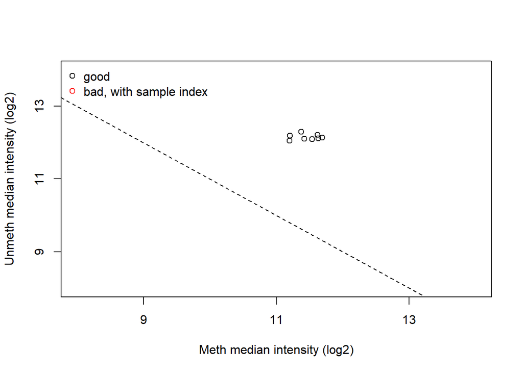

```r
qc <- getQC(MSet.raw)
plotQC(qc)
```

### 5b. Check the intensity of negative controls using minfi:

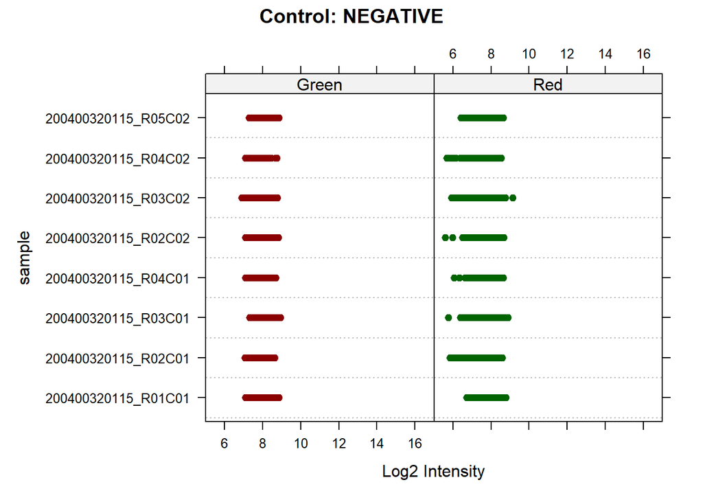

```r
controlStripPlot(RGset, controls="NEGATIVE")
```

### 5c. calculate detection pValues; and count, for each sample, how many probes have a detection p-value higher than 0.01

```r
detP <- detectionP(RGset)
failed <- detP>0.01
summary(failed)
```

```
##  200400320115_R01C01 200400320115_R02C01 200400320115_R03C01
##  Mode :logical       Mode :logical       Mode :logical
##  FALSE:485456        FALSE:485473        FALSE:485470
##  TRUE :56            TRUE :39            TRUE :42
##  200400320115_R04C01 200400320115_R02C02 200400320115_R03C02
##  Mode :logical       Mode :logical       Mode :logical
##  FALSE:485477        FALSE:485270        FALSE:485326
##  TRUE :35            TRUE :242           TRUE :186
##  200400320115_R04C02 200400320115_R05C02
##  Mode :logical       Mode :logical
##  FALSE:485491        FALSE:484962
##  TRUE :21            TRUE :550
```

### 6. Calculate raw beta and M values and plot the densities of mean methylation values, dividing the samples in WT and MUT.

```r
b <- getBeta(MSet.raw)
M <- getM(MSet.raw)
```

```r
M_MUT <- M[,c(targets$Group == 'MUT')]
M_WT <- M[,c(targets$Group == 'WT')]

b_MUT <- b[,c(targets$Group == 'MUT')]
b_WT <- b[,c(targets$Group == 'WT')]

mean_of_M_MUT <- apply(M_MUT,1,mean)
mean_of_M_MUT <- na.omit(mean_of_M_MUT)
d_mean_of_M_MUT <- density(mean_of_M_MUT)

mean_of_M_WT <- apply(M_WT,1,mean)
mean_of_M_WT <- na.omit(mean_of_M_WT)
d_mean_of_M_WT <- density(mean_of_M_WT)

mean_of_b_MUT <- apply(b_MUT,1,mean)
mean_of_b_MUT <- na.omit(mean_of_b_MUT)
d_mean_of_b_MUT <- density(mean_of_b_MUT)

mean_of_b_WT <- apply(b_WT,1,mean)
mean_of_b_WT <- na.omit(mean_of_b_WT)
d_mean_of_b_WT <- density(mean_of_b_WT)
```

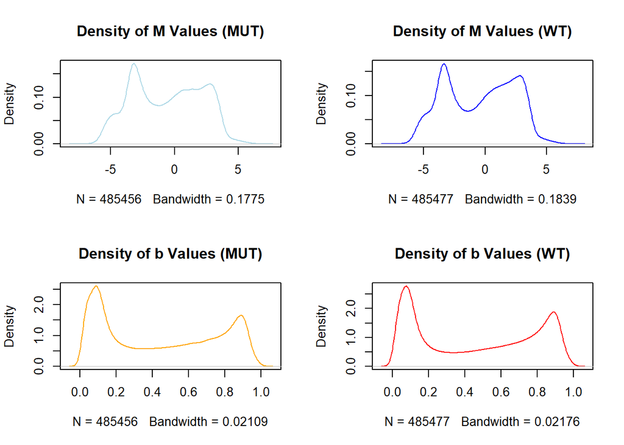

```r
par(mfrow=c(2,2))
plot(d_mean_of_M_MUT,main="Density of M Values (MUT)",col="lightblue")
plot(d_mean_of_M_WT,main="Density of M Values (WT)",col="blue")
plot(d_mean_of_b_MUT,main="Density of b Values (MUT)",col="orange")
plot(d_mean_of_b_WT,main="Density of b Values (WT)",col="red")
```

### 7. Normalize the data using ‘preprocessNoob’ and compare raw data and normalized data. Produce a plot with 6 panels in which, for both raw and normalized data, you show the density plots of beta mean values according to the chemistry of the probes, the density plot of beta standard deviation values according to the chemistry of the probes and the boxplot of beta values.

```r
dfI <- Illumina450Manifest_clean[Illumina450Manifest_clean$Infinium_Design_Type=="I",]
dfI <- droplevels(dfI)
dfII <- Illumina450Manifest_clean[Illumina450Manifest_clean$Infinium_Design_Type=="II",]
dfII <- droplevels(dfII)

b_I <- b[rownames(b) %in% dfI$IlmnID,]
b_II <- b[rownames(b) %in% dfII$IlmnID,]
```

```r
mean_of_b_I <- apply(b_I,1,mean)
mean_of_b_I <- na.omit(mean_of_b_I)
d_mean_of_b_I <- density(mean_of_b_I)

mean_of_b_II <- apply(b_II,1,mean)
mean_of_b_II <- na.omit(mean_of_b_II)
d_mean_of_b_II <- density(mean_of_b_II)
```

```r
sd_of_b_I <- apply(b_I,1,sd)
sd_of_b_I <- na.omit(sd_of_b_I)
d_sd_of_b_I <- density(sd_of_b_I,)

sd_of_b_II <- apply(b_II,1,sd)
sd_of_b_II <- na.omit(sd_of_b_II)
d_sd_of_b_II <- density(sd_of_b_II)

preprocessNoob_results <- preprocessNoob(RGset)
b_preprocessNoob <- getBeta(preprocessNoob_results)
```

```r
b_preprocessNoob_I <- b_preprocessNoob[rownames(b_preprocessNoob) %in% dfI$IlmnID,]
b_preprocessNoob_II <- b_preprocessNoob[rownames(b_preprocessNoob) %in% dfII$IlmnID,]
```

```r
mean_of_b_preprocessNoob_I <- apply(b_preprocessNoob_I,1,mean)
d_mean_of_b_preprocessNoob_I <- density(mean_of_b_preprocessNoob_I,na.rm=T)

mean_of_b_preprocessNoob_II <- apply(b_preprocessNoob_II,1,mean)
d_mean_of_b_preprocessNoob_II <- density(mean_of_b_preprocessNoob_II,na.rm=T)
```

```r
sd_of_b_preprocessNoob_I <- apply(b_preprocessNoob_I,1,sd)
d_sd_of_b_preprocessNoob_I <- density(sd_of_b_preprocessNoob_I,na.rm=T)

sd_of_b_preprocessNoob_II <- apply(b_preprocessNoob_II,1,sd)
d_sd_of_b_preprocessNoob_II <- density(sd_of_b_preprocessNoob_II,na.rm=T)
```

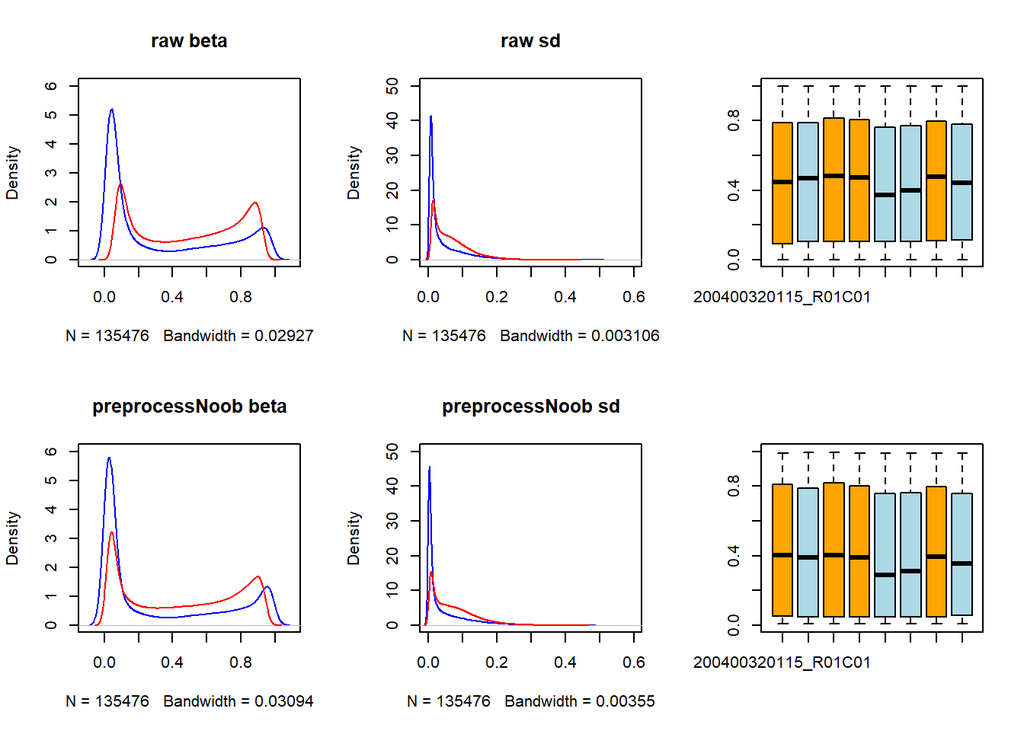

```r
Group = factor(targets$Group,levels = unique(targets$Group))

par(mfrow=c(2,3))
palette(c("orange","lightblue"))
plot(d_mean_of_b_I,col="blue",main="raw beta",xlim=c(-0.1,1.1),ylim=c(0,6))
lines(d_mean_of_b_II,col="red")
plot(d_sd_of_b_I,col="blue",main="raw sd",xlim=c(0,0.6),ylim=c(0,50))
lines(d_sd_of_b_II,col="red")
boxplot(b,col = Group,ylim=c(0,1))
plot(d_mean_of_b_preprocessNoob_I,col="blue",main="preprocessNoob beta",xlim=c(-0.1,1.1),ylim=c(0,6))
lines(d_mean_of_b_preprocessNoob_II,col="red")
plot(d_sd_of_b_preprocessNoob_I,col="blue",main="preprocessNoob sd",xlim=c(0,0.6),ylim=c(0,50))
lines(d_sd_of_b_preprocessNoob_II,col="red")
boxplot(b_preprocessNoob,col = Group,ylim=c(0,1))
```

### 8. PCA

```r
pca_results <- prcomp(t(b_preprocessNoob),scale=T)

samples = rownames(pca_results$x)
sample_labels = substr(samples, nchar(samples) - 5, nchar(samples))
```

#### 8a. Group

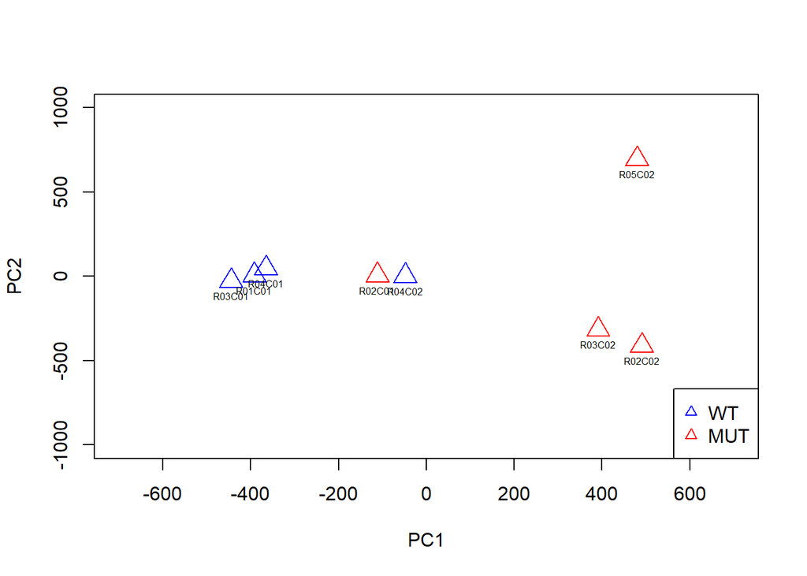

```r
palette(c("blue","red"))
plot(pca_results$x[,1], pca_results$x[,2],cex=2,pch=2,col=Group,xlab="PC1",ylab="PC2",xlim=c(-700,700),ylim=c(-1000,1000))
text(pca_results$x[,1], pca_results$x[,2],labels=sample_labels,cex=0.5,pos=1)
legend("bottomright",legend=levels(Group),col=c(1:nlevels(Group)),pch=2)
```

### 8b. Sex

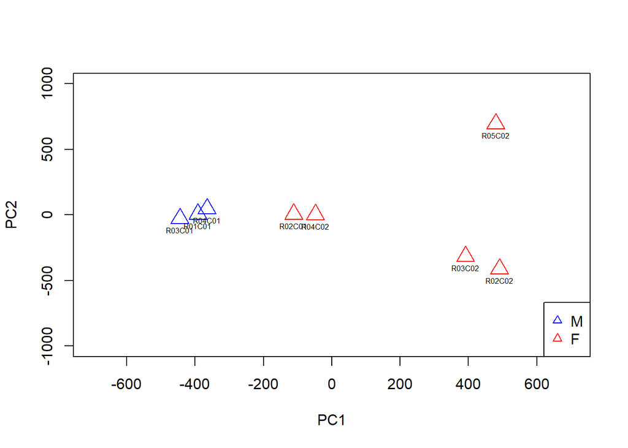

```r
Gender = factor(targets$Sex,levels = unique(targets$Sex))

palette(c("blue","red"))
plot(pca_results$x[,1], pca_results$x[,2],cex=2,pch=2,col=Gender,xlab="PC1",ylab="PC2",xlim=c(-700,700),ylim=c(-1000,1000))
text(pca_results$x[,1], pca_results$x[,2],labels=sample_labels,cex=0.5,pos=1)
legend("bottomright",legend=levels(Gender),col=c(1:nlevels(Gender)),pch=2)
```

### 8c. Batch

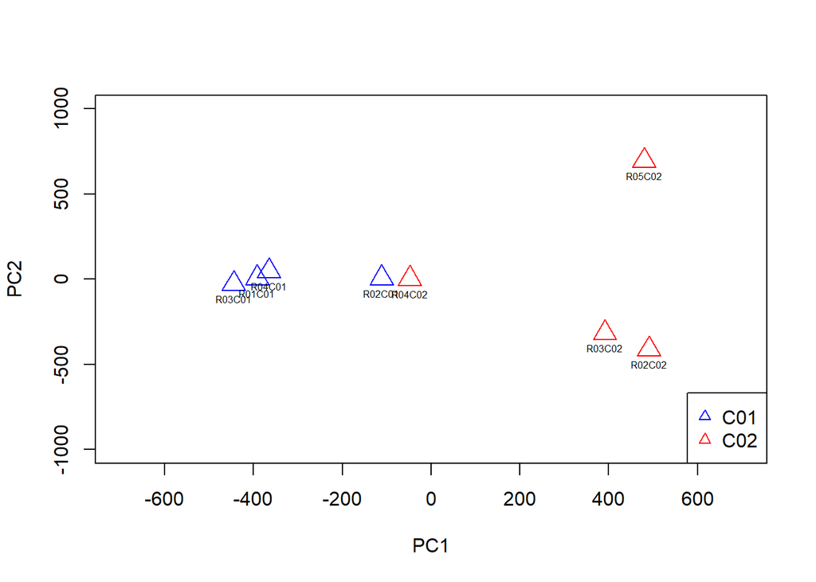

```r
sub_Sentrix_ID = substr(targets$Basename, start = nchar(targets$Basename) -2, stop = nchar(targets$Basename))
Batch = factor(sub_Sentrix_ID,levels = unique(sub_Sentrix_ID))

palette(c("blue","red"))
plot(pca_results$x[,1], pca_results$x[,2],cex=2,pch=2,col=Batch,xlab="PC1",ylab="PC2",xlim=c(-700,700),ylim=c(-1000,1000))
text(pca_results$x[,1], pca_results$x[,2],labels=sample_labels,cex=0.5,pos=1)
legend("bottomright",legend=levels(Batch),col=c(1:nlevels(Batch)),pch=2)
```

### 9. identify differentially methylated probes between group WT and group MUT using t-test.

```r
ttest_pvalue <- function(x) {
  t_test <- t.test(x~ Group)
  return(t_test$p.value)
}

pValues_ttest <- apply(b_preprocessNoob,1, ttest_pvalue)

final_ttest <- data.frame(b_preprocessNoob, pValues_ttest)

final_ttest_0.05 <- final_ttest[final_ttest$pValues_ttest<=0.05,]
dim(final_ttest_0.05)[1]
```

```
## [1] 63437
```

### 10. Apply multiple test correction with a significant threshold of 0.05.

```r
corrected_pValues_BH <- p.adjust(final_ttest$pValues_ttest,"BH")
corrected_pValues_Bonf <- p.adjust(final_ttest$pValues_ttest,"bonferroni")
final_ttest_corrected <- data.frame(final_ttest, corrected_pValues_BH, corrected_pValues_Bonf)

final_corrected_BH_0.05 <- final_ttest_corrected[final_ttest_corrected$corrected_pValues_BH<=0.05,]
dim(final_corrected_BH_0.05)[1]
```

```
## [1] 213
```

```r
final_corrected_Bonf_0.05 <- final_ttest_corrected[final_ttest_corrected$corrected_pValues_Bonf<=0.05,]
dim(final_corrected_Bonf_0.05)[1]
```

```
## [1] 5
```

### 11a. Volcano Plot

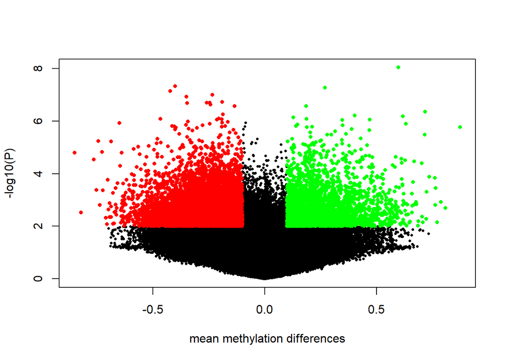

```r
b_preprocessNoob_groupMUT <- b_preprocessNoob[,Group=="MUT"]
mean_b_preprocessNoob_groupMUT <- apply(b_preprocessNoob_groupMUT,1,mean)
b_preprocessNoob_groupWT <- b_preprocessNoob[,Group=="WT"]
mean_b_preprocessNoob_groupWT <- apply(b_preprocessNoob_groupWT,1,mean)

delta <- mean_b_preprocessNoob_groupMUT-mean_b_preprocessNoob_groupWT

toVolcPlot <- data.frame(delta, -log10(final_ttest_corrected$pValues_ttest))

plot(toVolcPlot[,1], toVolcPlot[,2],pch=16,cex=0.5, xlab = "mean methylation differences", ylab = "-log10(P)")
Highlight_left <- toVolcPlot[toVolcPlot[,1]< -0.1 & toVolcPlot[,2]>(-log10(0.01)),]
Highlight_right <- toVolcPlot[toVolcPlot[,1]> 0.1 & toVolcPlot[,2]>(-log10(0.01)),]
points(Highlight_left[,1], Highlight_left[,2],pch=16,cex=0.7,col=("red"))
points(Highlight_right[,1], Highlight_right[,2],pch=16,cex=0.7,col=("green"))
```

### 11b. Manhattan Plot

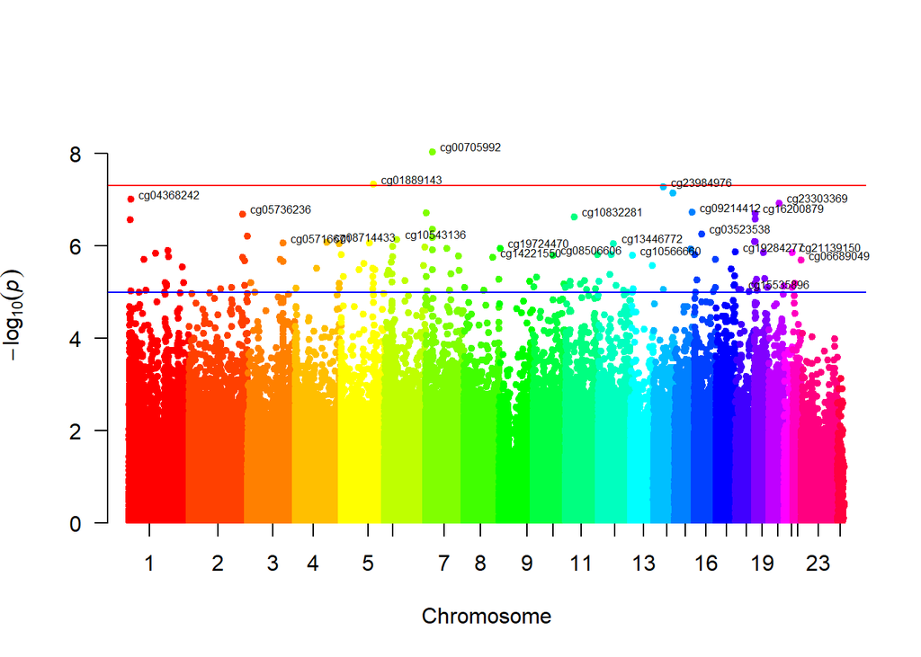

```r
suppressMessages(library(qqman))

final_ttest <- data.frame(rownames(final_ttest),final_ttest)
colnames(final_ttest)[1] <- "IlmnID"
final_ttest_annotated <- merge(final_ttest, Illumina450Manifest_clean,by="IlmnID")

input_Manhattan <- final_ttest_annotated[colnames(final_ttest_annotated) %in% c("IlmnID","CHR","MAPINFO","pValues_ttest")]
order_chr <- c("1","2","3","4","5","6","7","8","9","10","11","12","13","14","15","16","17","18","19","20","21","22","X","Y")
input_Manhattan$CHR <- factor(input_Manhattan$CHR,levels=order_chr )
input_Manhattan$CHR <- as.numeric(input_Manhattan$CHR)

manhattan(input_Manhattan, snp="IlmnID",chr="CHR", bp="MAPINFO", p="pValues_ttest",annotatePval = 0.00001,col= rainbow(24))
```

### 12. Heat Map - average linkage

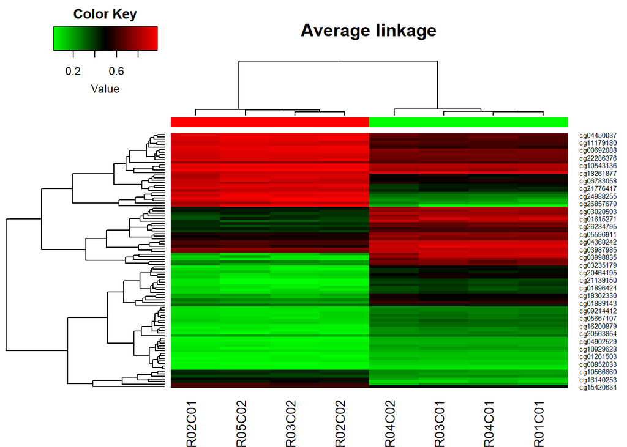

```r
suppressMessages(library(gplots))

final_ttest <- final_ttest[order(final_ttest$pValues_ttest),]
input_heatmap=as.matrix(final_ttest[1:100,2:9])

colorbar <- c("green","red","green","green","red","red","green","red")


col2=colorRampPalette(c("green","black","red"))(100)
heatmap.2(input_heatmap,col=col2,Rowv=T,Colv=T, hclustfun = function(x) hclust(x,method = 'average'), dendrogram="both",key=T,ColSideColors=colorbar,density.info="none",trace="none",scale="none",symm=F, main="Average linkage")
```